# Used-Cars-Price-Prediction - Avalons

Samba Chennamsetty, chennamsettys@mail.sacredheart.edu

Shaik Arif Pasha, shaiks11@mail.sacredheart.edu

Jagadishwar Reddy Velma, velmaj@mail.sacredheart.edu

[figure not shown]

Used Cars Inventory.

```r
library(tidyverse)
```

## Introduction

In this project we will explore the data set of Car Dekho. The data set is about second hand cars and various features of the Cars. The project will contain an Exploratory Data analysis, a Regression Model and Finally a Simple Supervised Machine Learning Model.

```r
df = read_csv("car_details.csv")
df
```

```
## # A tibble: 11,767 × 13
##    name          year selli…¹ km_dr…² fuel  selle…³ trans…⁴ owner mileage engine
##    <chr>        <dbl>   <dbl>   <dbl> <chr> <chr>   <chr>   <chr> <chr>   <chr>
##  1 Maruti Swif…  2014  450000  145500 Dies… Indivi… Manual  Firs… 23.4 k… 1248 …
##  2 Skoda Rapid…  2014  370000  120000 Dies… Indivi… Manual  Seco… 21.14 … 1498 …
##  3 Honda City …  2006  158000  140000 Petr… Indivi… Manual  Thir… 17.7 k… 1497 …
##  4 Hyundai i20…  2010  225000  127000 Dies… Indivi… Manual  Firs… 23.0 k… 1396 …
##  5 Maruti Swif…  2007  130000  120000 Petr… Indivi… Manual  Firs… 16.1 k… 1298 …
##  6 Hyundai Xce…  2017  440000   45000 Petr… Indivi… Manual  Firs… 20.14 … 1197 …
##  7 Maruti Wago…  2007   96000  175000 LPG   Indivi… Manual  Firs… 17.3 k… 1061 …
##  8 Maruti 800 …  2001   45000    5000 Petr… Indivi… Manual  Seco… 16.1 k… 796 CC
##  9 Toyota Etio…  2011  350000   90000 Dies… Indivi… Manual  Firs… 23.59 … 1364 …
## 10 Ford Figo D…  2013  200000  169000 Dies… Indivi… Manual  Firs… 20.0 k… 1399 …
## # … with 11,757 more rows, 3 more variables: max_power <chr>, torque <chr>,
## #   seats <dbl>, and abbreviated variable names ¹selling_price, ²km_driven,
## #   ³seller_type, ⁴transmission
```

## Data cleaning

Car Dekho is company which deals in used cars, this data have information about all the cars which are offered or registered in the portal to be sold. The data have various information like name of the car, Kilometer driven, mileage, engine power,age of the car etc. In this section using various function of tidyverse package we have cleaned the data. Numbers are extracted detaching them from their unit and also outliers are filtered. Using the *parse_number* function the numbers has been detached and with the use of *mutate* the parsed number is stored in a separate column. *filter* function is used to get rid of NULL values, 0 values and some outliers. The logical operators used in filter is according to the need of the data.

```r
df1 = df %>%
mutate(eng_pow = parse_number(engine),
      mil_num = parse_number(mileage),
      max_pow = parse_number(max_power),
      age= 2021-as.numeric(year)) %>%
mutate(Com = word(name,1))%>%
filter(!is.na(mil_num),
       !is.na(eng_pow),
      !is.na(max_pow),
      !mil_num == 0,
      !eng_pow == 0,
      !max_pow == 0,
      km_driven<550000,
      mil_num<35)
df1
```

```
## # A tibble: 11,425 × 18
##    name          year selli…¹ km_dr…² fuel  selle…³ trans…⁴ owner mileage engine
##    <chr>        <dbl>   <dbl>   <dbl> <chr> <chr>   <chr>   <chr> <chr>   <chr>
##  1 Maruti Swif…  2014  450000  145500 Dies… Indivi… Manual  Firs… 23.4 k… 1248 …
##  2 Skoda Rapid…  2014  370000  120000 Dies… Indivi… Manual  Seco… 21.14 … 1498 …
##  3 Honda City …  2006  158000  140000 Petr… Indivi… Manual  Thir… 17.7 k… 1497 …
##  4 Hyundai i20…  2010  225000  127000 Dies… Indivi… Manual  Firs… 23.0 k… 1396 …
##  5 Maruti Swif…  2007  130000  120000 Petr… Indivi… Manual  Firs… 16.1 k… 1298 …
##  6 Hyundai Xce…  2017  440000   45000 Petr… Indivi… Manual  Firs… 20.14 … 1197 …
##  7 Maruti Wago…  2007   96000  175000 LPG   Indivi… Manual  Firs… 17.3 k… 1061 …
##  8 Maruti 800 …  2001   45000    5000 Petr… Indivi… Manual  Seco… 16.1 k… 796 CC
##  9 Toyota Etio…  2011  350000   90000 Dies… Indivi… Manual  Firs… 23.59 … 1364 …
## 10 Ford Figo D…  2013  200000  169000 Dies… Indivi… Manual  Firs… 20.0 k… 1399 …
## # … with 11,415 more rows, 8 more variables: max_power <chr>, torque <chr>,
## #   seats <dbl>, eng_pow <dbl>, mil_num <dbl>, max_pow <dbl>, age <dbl>,
## #   Com <chr>, and abbreviated variable names ¹selling_price, ²km_driven,
## #   ³seller_type, ⁴transmission
```

```r
summary(df1)
```

```
##      name                year      selling_price       km_driven
##  Length:11425       Min.   :1994   Min.   :  29999   Min.   :     1
##  Class :character   1st Qu.:2012   1st Qu.: 270000   1st Qu.: 35000
##  Mode  :character   Median :2015   Median : 450000   Median : 60000
##                     Mean   :2014   Mean   : 651333   Mean   : 69039
##                     3rd Qu.:2017   3rd Qu.: 695000   3rd Qu.: 96000
##                     Max.   :2020   Max.   :7200000   Max.   :500000
##      fuel           seller_type        transmission          owner
##  Length:11425       Length:11425       Length:11425       Length:11425
##  Class :character   Class :character   Class :character   Class :character
##  Mode  :character   Mode  :character   Mode  :character   Mode  :character
##
##
##
##    mileage             engine           max_power            torque
##  Length:11425       Length:11425       Length:11425       Length:11425
##  Class :character   Class :character   Class :character   Class :character
##  Mode  :character   Mode  :character   Mode  :character   Mode  :character
##
##
##
##      seats           eng_pow        mil_num         max_pow
##  Min.   : 4.000   Min.   : 624   Min.   : 9.00   Min.   : 32.80
##  1st Qu.: 5.000   1st Qu.:1197   1st Qu.:16.78   1st Qu.: 68.05
##  Median : 5.000   Median :1248   Median :19.33   Median : 82.00
##  Mean   : 5.417   Mean   :1459   Mean   :19.47   Mean   : 91.65
##  3rd Qu.: 5.000   3rd Qu.:1582   3rd Qu.:22.32   3rd Qu.:102.00
##  Max.   :14.000   Max.   :3604   Max.   :33.44   Max.   :282.00
##       age             Com
##  Min.   : 1.000   Length:11425
##  1st Qu.: 4.000   Class :character
##  Median : 6.000   Mode  :character
##  Mean   : 7.019
##  3rd Qu.: 9.000
##  Max.   :27.000
```

## Data Visualization

Based on the summary we will be doing the EDA and will make some insight about the data. But before that in the following lines of code we have defined a customised theme for the following plots.

```r
theme_method = function(){
    font = "Times New Roman"

    theme_minimal() %+replace%

    theme(
      panel.background = element_rect(fill = "white",
            colour = NA), panel.border = element_rect(fill = NA,
            colour = "grey20"), panel.grid = element_line(colour = "grey92"),
            panel.grid.minor = element_line(size = rel(0.5)),
            strip.background = element_rect(fill = "grey85",
                colour = "grey20"), legend.key = element_rect(fill = "white",
                colour = NA), complete = TRUE,

      plot.title = element_text(
                   family = font,
                   size = 18,
                   face = 'bold.italic',
                   color = '#4040bf'),

      plot.subtitle = element_text(
                   family = font,
                   size = 14,
                   color = '#8080ff'),

      plot.caption = element_text(
                   family = font,
                   size = 9,
                   hjust = 1,
                   color = 'red'),

      axis.title = element_text(
                   family = font,
                   size = 13,
                   color = '#331a00'),

      axis.text = element_text(
                   family = font,
                   size = 9,
                   color = 'black'),

      axis.text.x = element_text(margin=margin(10, b = 10)))
    }
```

##### 1: This graph will show how the type of fuel affects the milage and Maximum Power of the Cars.

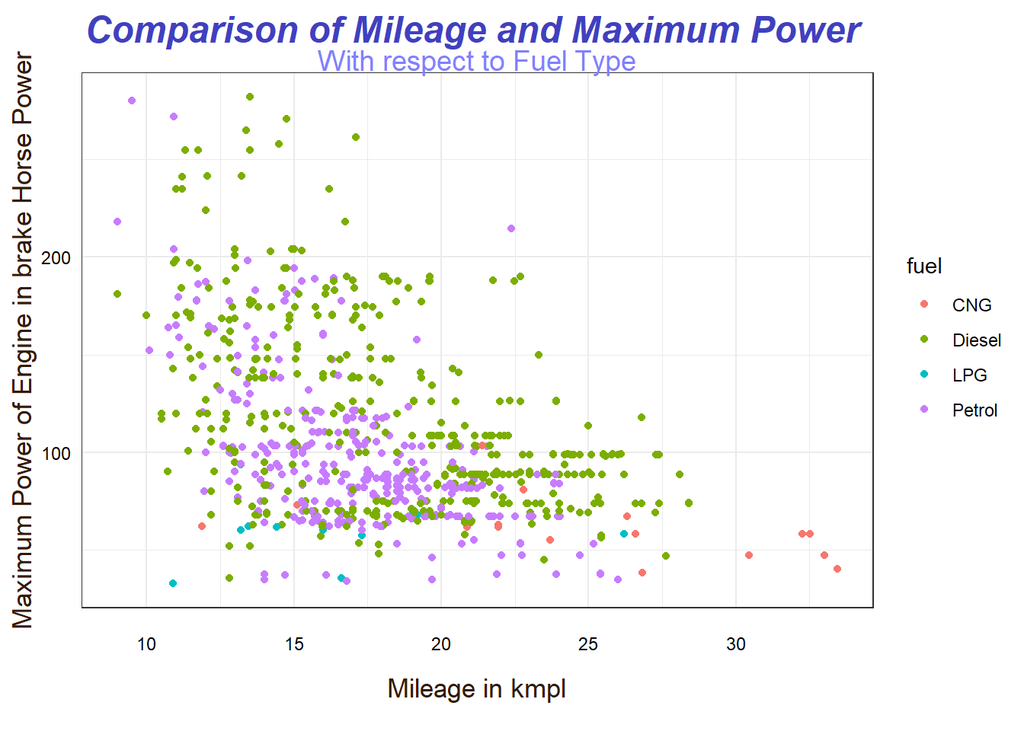

```r
df1%>%
filter(max_pow<300)%>%
ggplot()+geom_point(aes(x=mil_num,y=max_pow,color = fuel))+
labs(title = 'Comparison of Mileage and Maximum Power ',
     subtitle = 'With respect to Fuel Type',
    x= 'Mileage in kmpl',
    y='Maximum Power of Engine in brake Horse Power',
    caption = ' ')+
theme_method()
```

In this graph, we have a scatter plot where Mileage is on the x-axis and Engine power is on the y axis. Then the points have been classified based on the fuel type of the cars. A cluster of petrol cars is found in the 15 to 20 kmpl mileage, whereas no such cluster is found for diesel cars. LPG cars are of low Mileage and low Engine power, and in contrast to that, cars having CNG as fuel are of excellent efficiency. Cars with CNG have the highest Mileage. LPG found to be a more inefficient mode of fuel, but it could be cost-effective in real life, which is the limitation of the data.

##### 2: Box plot denoting the variation in selling price according to the fuel type of the cars.

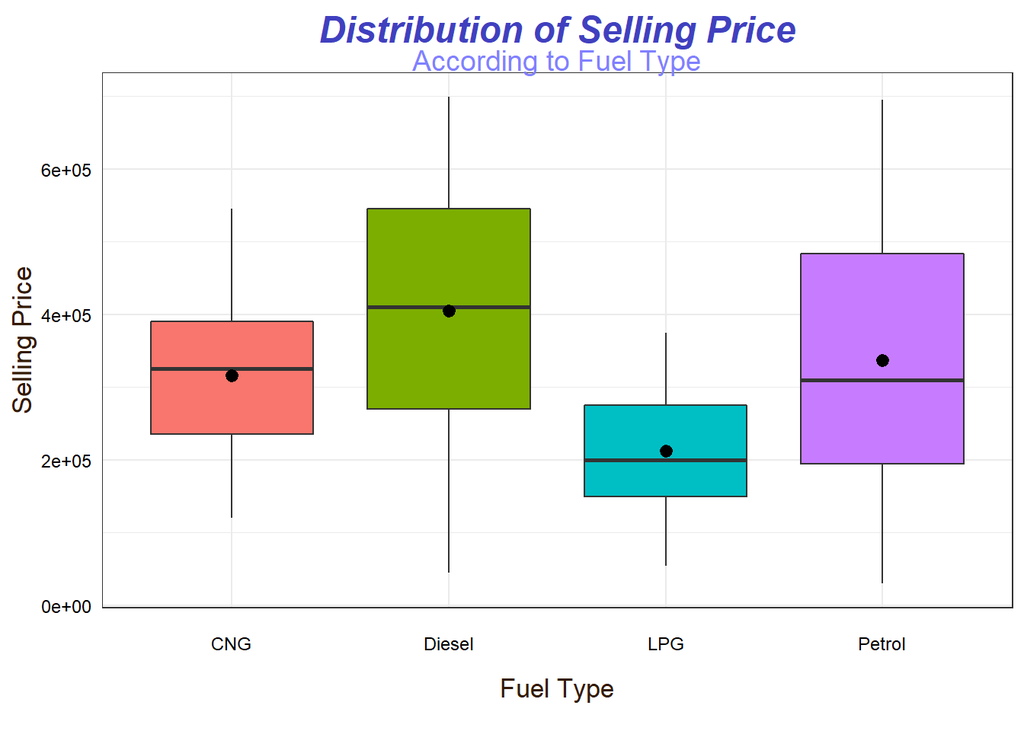

```r
options(warn=-1)
df1 %>%
filter(selling_price<700000,
       km_driven<700000)%>%
ggplot(aes(x=fuel,y=selling_price,fill=fuel))+
geom_boxplot(show.legend = FALSE)+
stat_summary(fun="mean",show.legend = FALSE)+
labs(title = 'Distribution of Selling Price',
    subtitle = 'According to Fuel Type',
    x= 'Fuel Type',
    y='Selling Price',
    caption = ' ')+
theme_method()
```

Here in the diagram we can we have the Box plot of the distribution of selling price along with Fuel Type. As we all know the lower horizontal side of the box tells us about first quartile and the upper side shows third quartile. The line in between shows the median of the distribution. Along with that using *stat_summary*, the mean value of each class are plotted as a point. From the distribution it is clear that the on an average the selling price of LPG car is the lowest, whereas the Concentration of Diesel car is at higher selling price section. For Petrol cars we can observe that the mean value of the cars is higher than the middle most value. We can say that the distribution is positively skewed which means there are less number of cars with very high selling price. For Diesel car the distribution is almost symmetric.

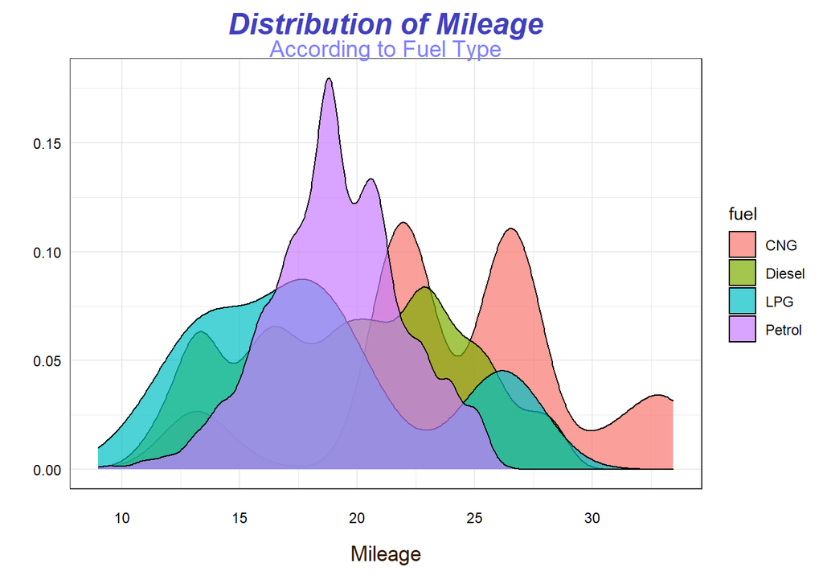

```r
options(warn=-1)
df1 %>%
ggplot(aes(x=mil_num,fill=fuel))+
geom_density(alpha = 0.7)+
labs(title = 'Distribution of Mileage',
    subtitle = 'According to Fuel Type',
    x= 'Mileage',
    y='',
    caption = ' ')+
theme_method()
```

##### 3: Box plot showing distribution of Cars along with selling price considering owner as a factor.

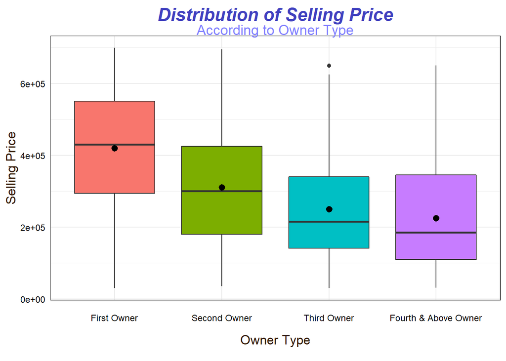

```r
df_f=df1 %>%
filter(selling_price<700000,
       km_driven<700000)
df_f$owner=factor(df_f$owner,levels=c('First Owner','Second Owner','Third Owner','Fourth & Above Owner'))
ggplot(data=df_f,aes(x=owner,y=selling_price,fill=owner))+
geom_boxplot(show.legend = FALSE)+
stat_summary(fun="mean",show.legend = FALSE)+
labs(title = 'Distribution of Selling Price',
    subtitle = 'According to Owner Type',
    x= 'Owner Type',
    y='Selling Price',
    caption = ' ')+
theme_method()
```

##### 4: Histogram Depicting the Distribution of Cars over age of it.

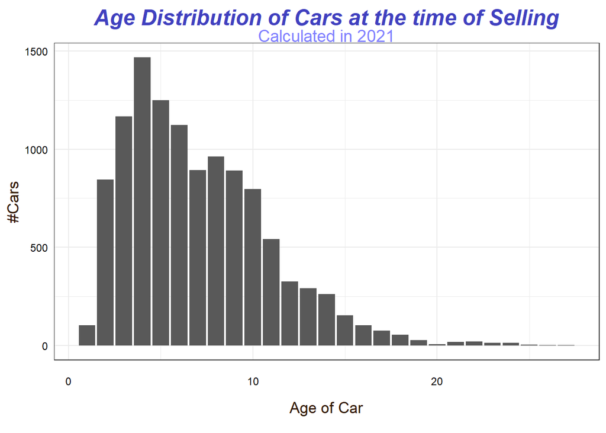

```r
df1%>%
group_by(age)%>%
count()%>%
ggplot()+geom_col(aes(y=n,x=age))+
labs(title = 'Age Distribution of Cars at the time of Selling',
     subtitle= 'Calculated in 2021',
    x= 'Age of Car',
    y='#Cars',
    caption = '')+
theme_method()
```

This bar diagram will show the distribution of Nature of Ownership based on Fuel Type.

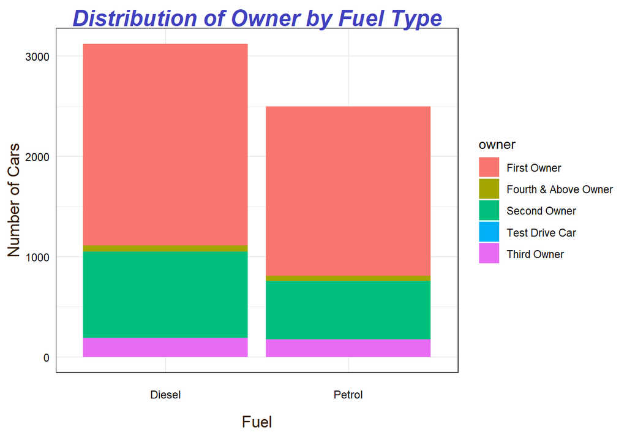

```r
df1 %>%
filter(fuel == c('Diesel','Petrol'))%>%
ggplot()+geom_bar(aes(x=fuel, fill = owner, order = owner))+
labs(title = 'Distribution of Owner by Fuel Type',
    x= 'Fuel',
    y='Number of Cars',
    caption = ' ')+theme_method()
```

This diagram will help in determing how fuel type can influence Engine Power. Along with that there is a high probability of the collinearity in the case of regression model.

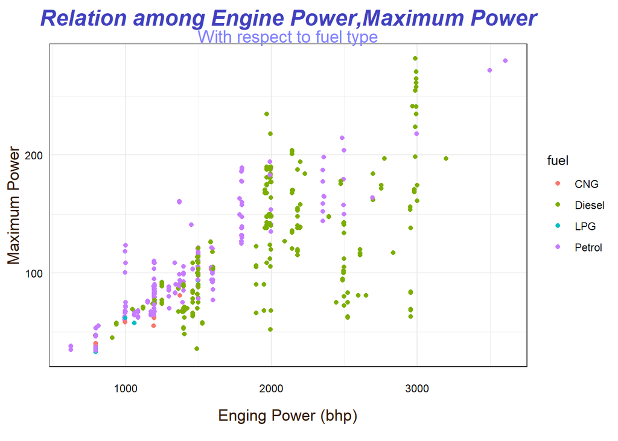

```r
df1%>%
filter(max_pow<300)%>%
ggplot()+geom_point(aes(x=eng_pow,y=max_pow,color=fuel))+
labs(title = 'Relation among Engine Power,Maximum Power',
     subtitle = 'With respect to fuel type',
    x= 'Enging Power (bhp)',
    y='Maximum Power',
    caption = ' ')+theme_method()
```

Distribution of Major Companies in second hand Market.

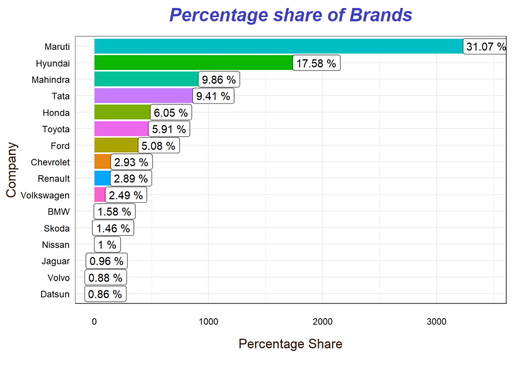

```r
df1%>%
group_by(Com)%>%
count()%>%
arrange(desc(n))%>%
filter(n>90)%>%
ggplot()+geom_col(aes(x=n,y=reorder(Com,n),fill=Com),show.legend = FALSE)+
geom_label(aes(y = reorder(Com,n), x = n, label = paste(round((n/sum(n))*100,2),'%')))+
labs(title = 'Percentage share of Brands',
     subtitle = '',
    x= 'Percentage Share',
    y='Company',
    caption = ' ')+
theme_method()
```

## Regression Model Dummy Variable Creation

```r
library(dummy)
library(fastDummies)
df2=dummy_cols(df1[,c(5,6,7,8)],remove_first_dummy=TRUE)
#df2
```

Combining the Dummy Variable table with Main data frame.

```r
df3=cbind(df1,df2[,5:14])
#names(df3)
#df3
```

Regression Analysis

```r
df4=df3[,c(3:4,15:17,19:28)]
#names(df4)
lm2=lm(log(selling_price) ~.,data=df4)
summary(lm2)
```

```
##
## Call:
## lm(formula = log(selling_price) ~ ., data = df4)
##
## Residuals:
##      Min       1Q   Median       3Q      Max
## -1.76523 -0.17307  0.01401  0.19751  1.92284
##
## Coefficients:
##                                  Estimate Std. Error  t value Pr(>|t|)
## (Intercept)                     1.310e+01  4.833e-02  271.153  < 2e-16 ***
## km_driven                      -4.408e-07  7.655e-08   -5.758 8.71e-09 ***
## mil_num                        -8.032e-03  9.384e-04   -8.558  < 2e-16 ***
## max_pow                         1.126e-02  1.205e-04   93.463  < 2e-16 ***
## age                            -1.137e-01  1.038e-03 -109.535  < 2e-16 ***
## fuel_Diesel                     2.415e-01  3.444e-02    7.013 2.47e-12 ***
## fuel_LPG                        9.666e-02  5.504e-02    1.756  0.07908 .
## fuel_Petrol                    -3.705e-02  3.453e-02   -1.073  0.28334
## seller_type_Individual         -1.086e-01  9.141e-03  -11.880  < 2e-16 ***
## `seller_type_Trustmark Dealer`  5.242e-02  1.855e-02    2.826  0.00472 **
## transmission_Manual            -1.733e-01  1.077e-02  -16.094  < 2e-16 ***
## `owner_Fourth & Above Owner`   -1.475e-01  2.149e-02   -6.866 6.93e-12 ***
## `owner_Second Owner`           -6.810e-02  7.333e-03   -9.286  < 2e-16 ***
## `owner_Test Drive Car`          5.644e-01  9.652e-02    5.848 5.12e-09 ***
## `owner_Third Owner`            -1.166e-01  1.267e-02   -9.208  < 2e-16 ***
## ---
## Signif. codes:  0 '***' 0.001 '**' 0.01 '*' 0.05 '.' 0.1 ' ' 1
##
## Residual standard error: 0.3037 on 11410 degrees of freedom
## Multiple R-squared:  0.8662, Adjusted R-squared:  0.866
## F-statistic:  5275 on 14 and 11410 DF,  p-value: < 2.2e-16
```

```r
(summary(lm2)$coefficient)
```

```
##                                     Estimate   Std. Error     t value
## (Intercept)                     1.310437e+01 4.832828e-02  271.153168
## km_driven                      -4.408095e-07 7.654961e-08   -5.758482
## mil_num                        -8.031581e-03 9.384365e-04   -8.558470
## max_pow                         1.126313e-02 1.205091e-04   93.462881
## age                            -1.136949e-01 1.037980e-03 -109.534765
## fuel_Diesel                     2.415402e-01 3.444345e-02    7.012660
## fuel_LPG                        9.666450e-02 5.504257e-02    1.756177
## fuel_Petrol                    -3.704934e-02 3.453199e-02   -1.072899
## seller_type_Individual         -1.085919e-01 9.140988e-03  -11.879667
## `seller_type_Trustmark Dealer`  5.242097e-02 1.854681e-02    2.826415
## transmission_Manual            -1.732692e-01 1.076603e-02  -16.094056
## `owner_Fourth & Above Owner`   -1.475377e-01 2.148700e-02   -6.866369
## `owner_Second Owner`           -6.809796e-02 7.333016e-03   -9.286487
## `owner_Test Drive Car`          5.644099e-01 9.652028e-02    5.847579
## `owner_Third Owner`            -1.166297e-01 1.266664e-02   -9.207628
##                                    Pr(>|t|)
## (Intercept)                    0.000000e+00
## km_driven                      8.706411e-09
## mil_num                        1.289876e-17
## max_pow                        0.000000e+00
## age                            0.000000e+00
## fuel_Diesel                    2.470421e-12
## fuel_LPG                       7.908499e-02
## fuel_Petrol                    2.833391e-01
## seller_type_Individual         2.341621e-32
## `seller_type_Trustmark Dealer` 4.715410e-03
## transmission_Manual            1.208388e-57
## `owner_Fourth & Above Owner`   6.927551e-12
## `owner_Second Owner`           1.882368e-20
## `owner_Test Drive Car`         5.124544e-09
## `owner_Third Owner`            3.914141e-20
```

## Regression Diagnostic Test

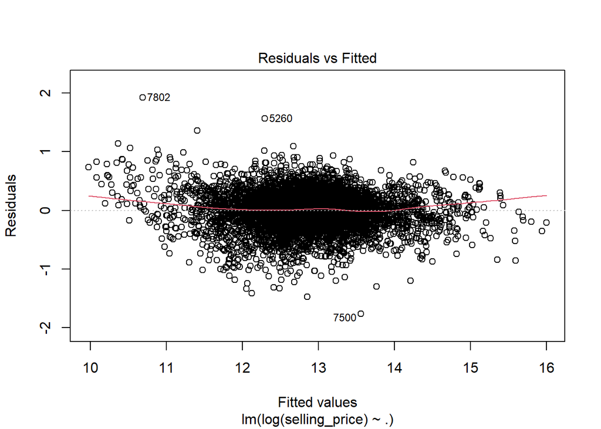

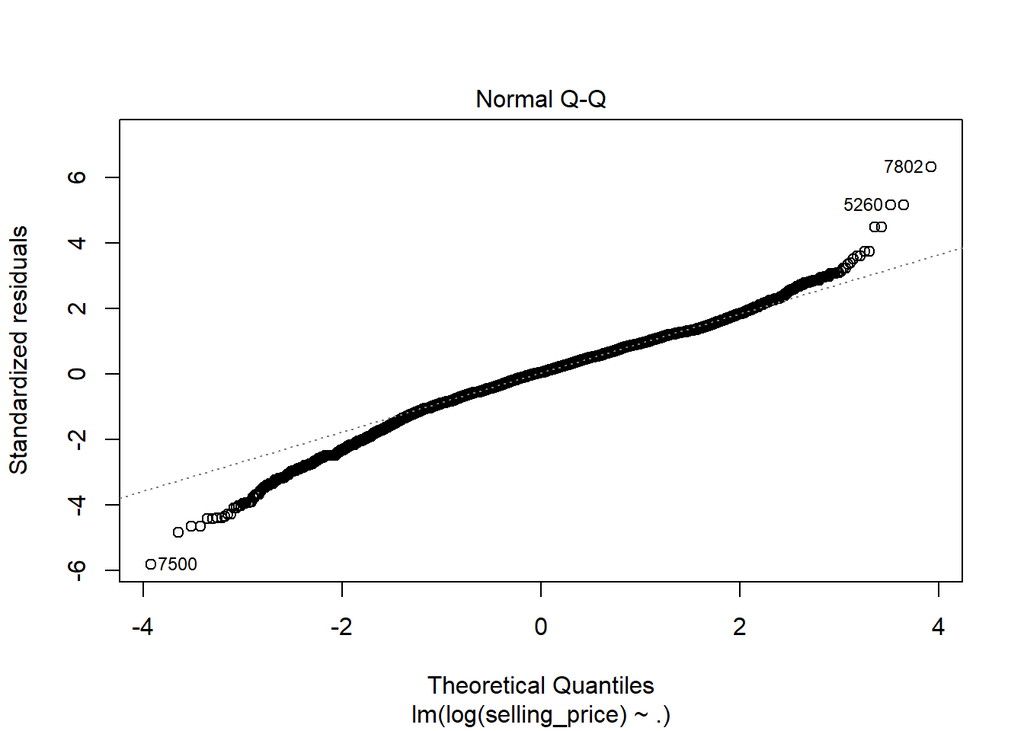

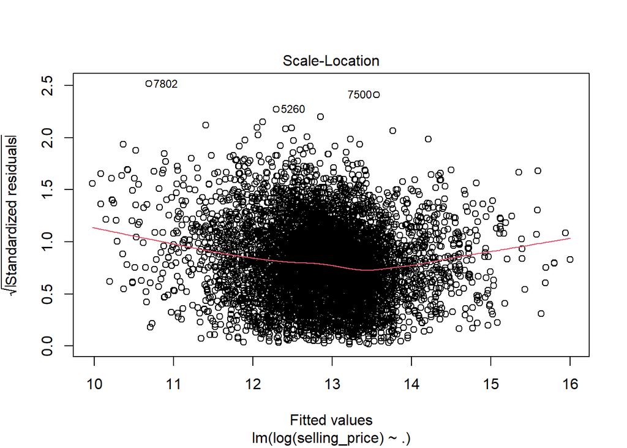

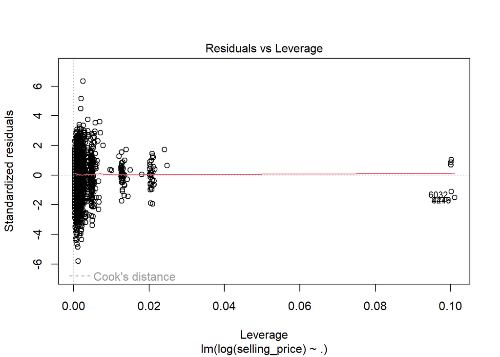

```r
plot(lm2)
```

In an ideal and unbiased regression, the red lines in the first and third diagram should have been parallel to x axis. So, these two results are more or less acceptable. In the second diagram for ideal regression the points should lie on the diagonal line, our result is also not that bad to reject the model.

```r
#library(corpcor)
#cor2pcor(cov(df4))
```

## Test of Multicollinearity

```r
library(car)
data.frame(vif(lm2))
```

```
##                                 vif.lm2.
## km_driven                       1.679470
## mil_num                         1.687382
## max_pow                         2.264427
## age                             2.015875
## fuel_Diesel                    36.377168
## fuel_LPG                        1.634927
## fuel_Petrol                    36.380138
## seller_type_Individual          1.455239
## `seller_type_Trustmark Dealer`  1.223062
## transmission_Manual             1.640020
## `owner_Fourth & Above Owner`    1.099097
## `owner_Second Owner`            1.275576
## `owner_Test Drive Car`          1.009003
## `owner_Third Owner`             1.206700
```

According to the rule of thumb of the value VIF we know that, A VIF value of greater than 10 signifies that the amount of Multicollinearity can cost some problem to the data set. In our analysis we can find that only Fuel Type Petrol and Fuel Type Diesel are crossing the limit 10. Apart from that other variables are not showing some significant problem. From the formula of VIF we know that the minimum value of VIF is 1 and for this data set most of the values are close to 1.

A solution to this problem could be dropping of the Fuel variable as it is making some disturbances in the Model.

## Test of Autocorrelation

```r
library(lmtest)
dwtest(lm2)
```

```
##
##  Durbin-Watson test
##
## data:  lm2
## DW = 1.863, p-value = 1.013e-13
## alternative hypothesis: true autocorrelation is greater than 0
```

```r
bgtest(lm2)
```

```
##
##  Breusch-Godfrey test for serial correlation of order up to 1
##
## data:  lm2
## LM test = 54.103, df = 1, p-value = 1.903e-13
```

## Test of Homoscedasticity

```r
bptest(lm2)
```

```
##
##  studentized Breusch-Pagan test
##
## data:  lm2
## BP = 1261.1, df = 14, p-value < 2.2e-16
```

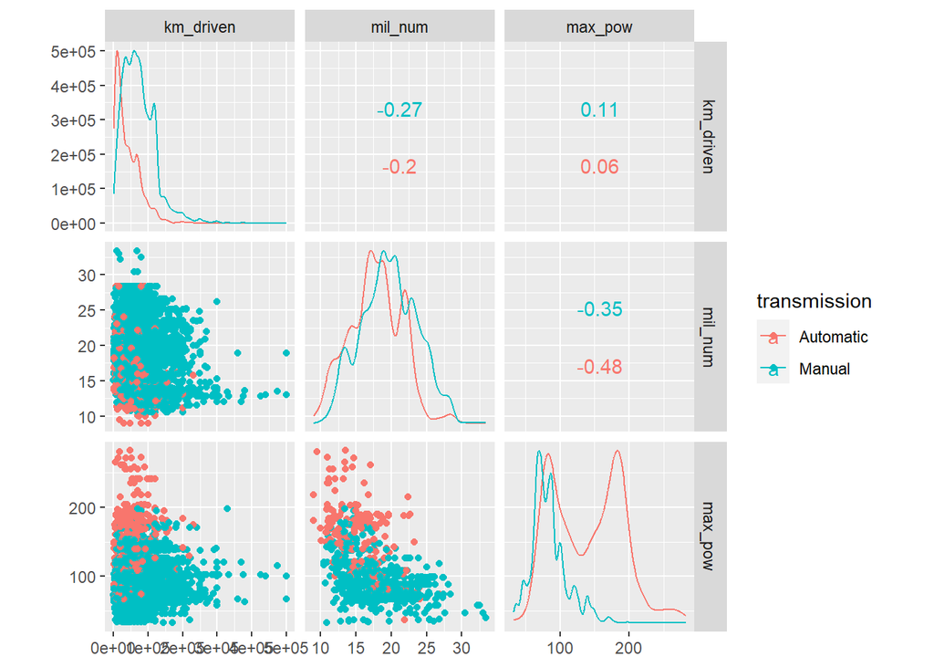

```r
#names(df4)
library(GGally)
library(grid)
ggscatmat(df1, columns = c(4,15,16), color = "transmission")
```

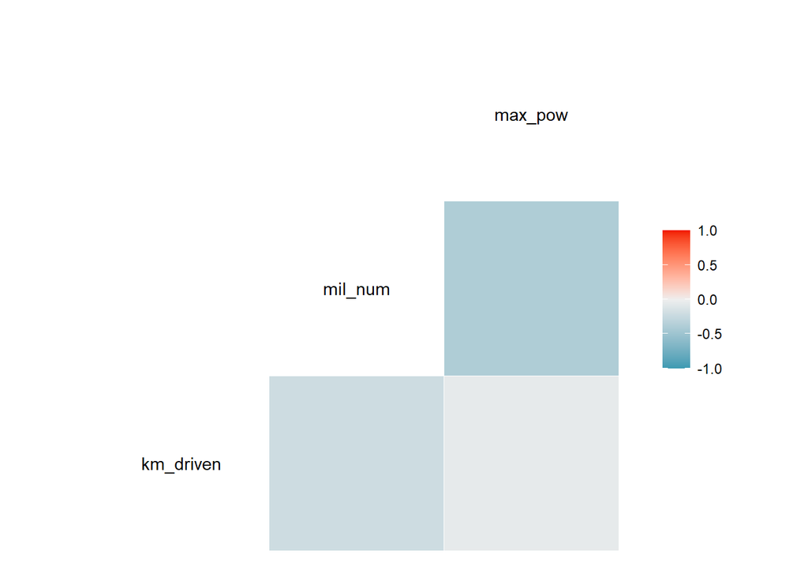

```r
ggcorr(df4[2:4])
```

## Supervised ML

```r
split_size = 0.9
sample_size = floor(split_size * nrow(df4))
set.seed(2037001)
train_indices = sample(seq_len(nrow(df4)), size = sample_size)
train = df4[train_indices,]
test = df4[-train_indices,]
model2= lm(selling_price ~.,data=train)
#summary(model2)
#View(train)
new.data = test[,-1]
test$output = predict(model2, new.data)
#test$output
sqrt(sum(test$selling_price - test$output)^2/nrow(test))
```

```
## [1] 236924.4
```

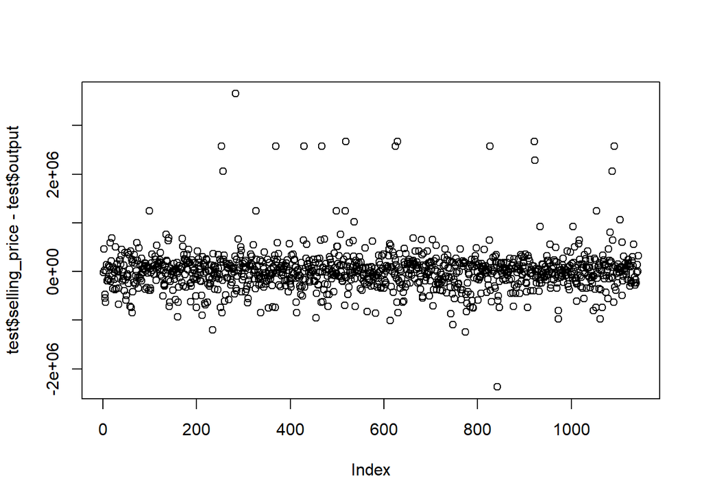

```r
plot(test$selling_price - test$output)
```

```r
names(df1)
```

```
##  [1] "name"          "year"          "selling_price" "km_driven"
##  [5] "fuel"          "seller_type"   "transmission"  "owner"
##  [9] "mileage"       "engine"        "max_power"     "torque"
## [13] "seats"         "eng_pow"       "mil_num"       "max_pow"
## [17] "age"           "Com"
```

```r
str(df1)
```

```
## tibble [11,425 × 18] (S3: tbl_df/tbl/data.frame)
##  $ name         : chr [1:11425] "Maruti Swift Dzire VDI" "Skoda Rapid 1.5 TDI Ambition" "Honda City 2017-2020 EXi" "Hyundai i20 Sportz Diesel" ...
##  $ year         : num [1:11425] 2014 2014 2006 2010 2007 ...
##  $ selling_price: num [1:11425] 450000 370000 158000 225000 130000 440000 96000 45000 350000 200000 ...
##  $ km_driven    : num [1:11425] 145500 120000 140000 127000 120000 ...
##  $ fuel         : chr [1:11425] "Diesel" "Diesel" "Petrol" "Diesel" ...
##  $ seller_type  : chr [1:11425] "Individual" "Individual" "Individual" "Individual" ...
##  $ transmission : chr [1:11425] "Manual" "Manual" "Manual" "Manual" ...
##  $ owner        : chr [1:11425] "First Owner" "Second Owner" "Third Owner" "First Owner" ...
##  $ mileage      : chr [1:11425] "23.4 kmpl" "21.14 kmpl" "17.7 kmpl" "23.0 kmpl" ...
##  $ engine       : chr [1:11425] "1248 CC" "1498 CC" "1497 CC" "1396 CC" ...
##  $ max_power    : chr [1:11425] "74 bhp" "103.52 bhp" "78 bhp" "90 bhp" ...
##  $ torque       : chr [1:11425] "190Nm@ 2000rpm" "250Nm@ 1500-2500rpm" "12.7@ 2,700(kgm@ rpm)" "22.4 kgm at 1750-2750rpm" ...
##  $ seats        : num [1:11425] 5 5 5 5 5 5 5 4 5 5 ...
##  $ eng_pow      : num [1:11425] 1248 1498 1497 1396 1298 ...
##  $ mil_num      : num [1:11425] 23.4 21.1 17.7 23 16.1 ...
##  $ max_pow      : num [1:11425] 74 103.5 78 90 88.2 ...
##   ..- attr(*, "problems")= tibble [2 × 4] (S3: tbl_df/tbl/data.frame)
##   .. ..$ row     : int [1:2] 4934 9284
##   .. ..$ col     : int [1:2] NA NA
##   .. ..$ expected: chr [1:2] "a number" "a number"
##   .. ..$ actual  : chr [1:2] "bhp" "bhp"
##  $ age          : num [1:11425] 7 7 15 11 14 4 14 20 10 8 ...
##  $ Com          : chr [1:11425] "Maruti" "Skoda" "Honda" "Hyundai" ...
```